# casestudy1

Malcolm Carlson

10/4/2019

```r
library(magrittr)
library(dplyr)
library(tidyverse)
library(mice)
```

```r
library(usmap)
library(ggplot2)
library(stringr)


#beerdf=read.csv("C:\\Users\\malco\\Documents\\MDS\\MDS_6306_DDS\\CaseS#tudy1\\Beers.csv",header=TRUE)
#breweriesdf=read.csv("C:\\Users\\malco\\Documents\\MDS\\MDS_6306_DDS\\CaseStudy1\\Breweries.csv",header=TRUE)
#IBU - International Bitterness Units
#ABV - Alcohol by Volume

#Cleanup to enable a key with same name
#Brew_ID,Name,City,State
#breweriesdf <- breweriesdf %>% rename(
#  Brewery_id = Brew_ID,
#   Brewery_name = Name
#)

#Change name to be more unique
#beerdf <- beerdf %>% rename(
#  Beer_name = Name
#)


#combineddf<-merge(breweriesdf,beerdf, by="Brewery_id",all = TRUE)
#sum(is.na(combineddf$ABV))
#sum(is.na(combineddf$IBU))

nona=read.csv(file="/Users/malco/Documents/MDS/MDS_6306_DDS/CaseStudy1/nona.csv",header=TRUE)
#view(nona)
```

#1. How many breweries are present in each state?

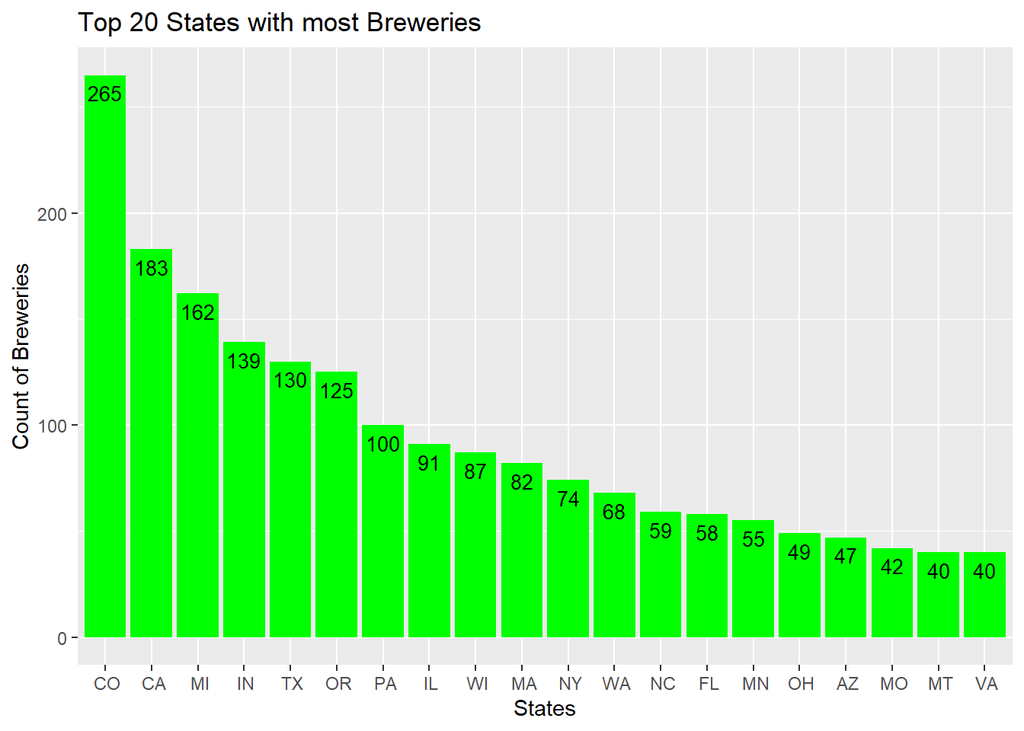

```r
#Createt for data in ascending order
stateSum=nona%>%group_by(State)%>%summarise(Brewery_count=n())
orderedstateSum<-stateSum[order(-stateSum$Brewery_count),]
#Top 20 ordered bar chart

top20=head(orderedstateSum,20)
top20%>%ggplot(aes(x=reorder(State,-Brewery_count),y=Brewery_count))+
  geom_bar(stat="identity",fill="green")+
  geom_text(aes(label=Brewery_count), vjust=1.6, color="black", size=3.5)+
  ggtitle("Top 20 States with most Breweries")+xlab("States")+ylab("Count of Breweries")
```

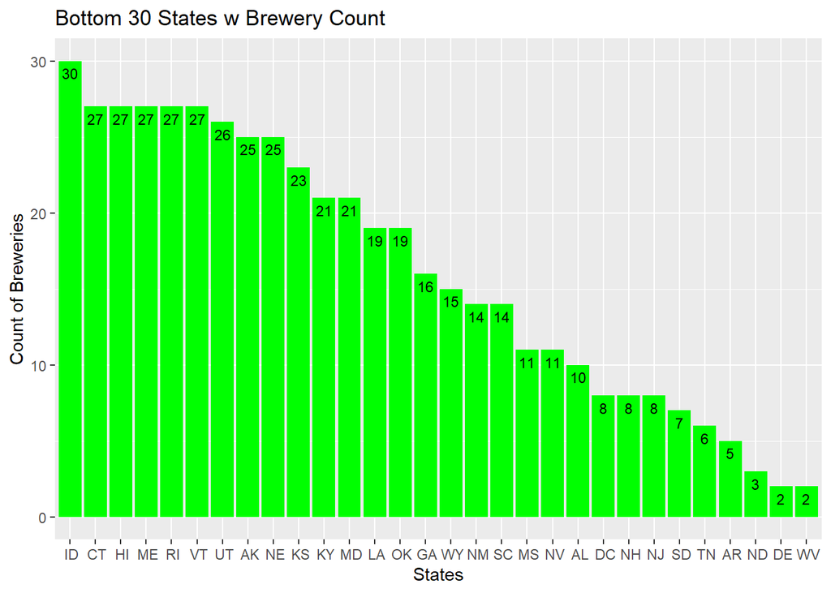

```r
#Bottom 30 ordered bar chart
bottom30=tail(orderedstateSum,30)
#view(bottom30)
bottom30%>%ggplot(aes(x=reorder(State,-Brewery_count),y=Brewery_count))+
  geom_bar(stat="identity",fill="green")+geom_text(aes(label=Brewery_count), vjust=1.6, color="black", size=3)+
  ggtitle("Bottom 30 States w Brewery Count")+xlab("States")+ylab("Count of Breweries")
```

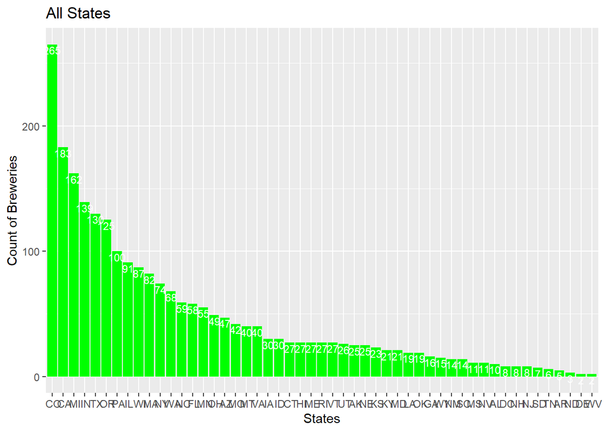

```r
orderedstateSum%>%ggplot(aes(x=reorder(State,-Brewery_count),y=Brewery_count))+
  geom_bar(stat="identity",fill="green")+
  geom_text(aes(label=Brewery_count), vjust=1.2, color="white", size=3)+
  ggtitle("All States")+xlab("States")+ylab("Count of Breweries")
```

```r
#map of 50 states with # of breweries?
```

```r
top6merge<-head(nona)
bottom6merge<-tail(nona)
view(top6merge,title = "Top 6 head data for merged dataset")
view(bottom6merge,title = "Bottom 6 head data for merged dataset")
```

#3. Address the missing values in each column. #Uncomment to re-run imputation

```r
#init = mice(combineddf, maxit=0)
#predM = init$predictorMatrix
#predM[, c("Beer_name", "Beer_ID", "Ounces", "Brewery_name")]=0
#imp<-mice(combineddf, m=5, predictorMatrix = predM)
#nona <- complete(imp)
#view(nona)
#nona$State<-trimws(nona$State)
#write.csv(nona,file="/Users/malco/Documents/MDS/MDS_6306_DDS/CaseStudy1/nona.csv",row.names=FALSE)
nona=read.csv(file="/Users/malco/Documents/MDS/MDS_6306_DDS/CaseStudy1/nona.csv",header=TRUE)
#view(nona)
```

```r
nona$State = as.character(nona$State)
nona$State = str_trim(nona$State)
#Dataframe of just State,ABV,IBU
medianABVIBU<-nona%>%group_by(State)%>%summarize(medianABV=median(ABV),medianIBU=median(IBU))
head(medianABVIBU)
```

```
## # A tibble: 6 x 3
##   State medianABV medianIBU
##   <chr>     <dbl>     <dbl>
## 1 AK        0.056      40
## 2 AL        0.06       39.5
## 3 AR        0.052      40
## 4 AZ        0.055      20
## 5 CA        0.058      60
## 6 CO        0.059      40
```

```r
#Code for Top 20 highes ABV by State
top20medABV=head(medianABVIBU,20)
top20medABV<-top20medABV%>%select(State,medianABV)
head(top20medABV)
```

```
## # A tibble: 6 x 2
##   State medianABV
##   <chr>     <dbl>
## 1 AK        0.056
## 2 AL        0.06
## 3 AR        0.052
## 4 AZ        0.055
## 5 CA        0.058
## 6 CO        0.059
```

[figure not shown]

```r
top20medABV%>%ggplot(aes(x=reorder(State,-medianABV),y=medianABV))+
  geom_bar(stat="identity",fill="green")+geom_text(aes(label=medianABV), vjust=1.6, color="black", size=3)+
ggtitle("Highest Median Alcohol by Volumes by State")+xlab("States")+ylab("Alcohol by Volume")
```

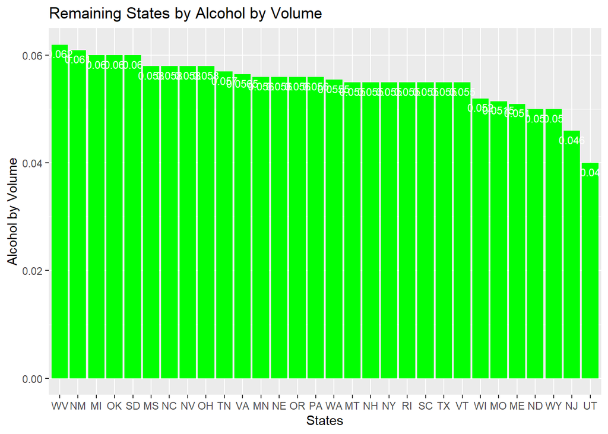

```r
#Code for ascending ordered ABV by State
remainingABV=tail(medianABVIBU,30)
remainingABV<-remainingABV%>%select(State,medianABV)
remainingABV%>%ggplot(aes(x=reorder(State,-medianABV),y=medianABV))+
  geom_bar(stat="identity",fill="green")+geom_text(aes(label=medianABV), vjust=1.6, color="white", size=3)+
ggtitle("Remaining States by Alcohol by Volume")+xlab("States")+ylab("Alcohol by Volume")
```

```r
head(top20medABV)
```

```
## # A tibble: 6 x 2
##   State medianABV
##   <chr>     <dbl>
## 1 AK        0.056
## 2 AL        0.06
## 3 AR        0.052
## 4 AZ        0.055
## 5 CA        0.058
## 6 CO        0.059
```

#5. Which state has the maximum alcoholic (ABV) beer? Which #state has the most bitter (IBU) #beer?

```r
#Code to selct by ABV and IBU and find max value
maxABV<-nona%>%group_by(State)%>%select(State,ABV)
maxIBU<-nona%>%group_by(State)%>%select(State,IBU)
maxABV[which.max(maxABV$ABV), ]
```

```
## # A tibble: 1 x 2
## # Groups:   State [1]
##   State   ABV
##   <chr> <dbl>
## 1 CO    0.128
```

```r
maxIBU[which.max(maxIBU$IBU), ]
```

```
## # A tibble: 1 x 2
## # Groups:   State [1]
##   State   IBU
##   <chr> <int>
## 1 CO      138
```

```r
#need bar chart of top 10
```

#6. Comment on the summary statistics and distribution of the #ABV variable.

```r
justABV<-nona%>%select(ABV)
summary(justABV)
```

```
##       ABV
##  Min.   :0.00100
##  1st Qu.:0.05000
##  Median :0.05600
##  Mean   :0.05933
##  3rd Qu.:0.06700
##  Max.   :0.12800
```

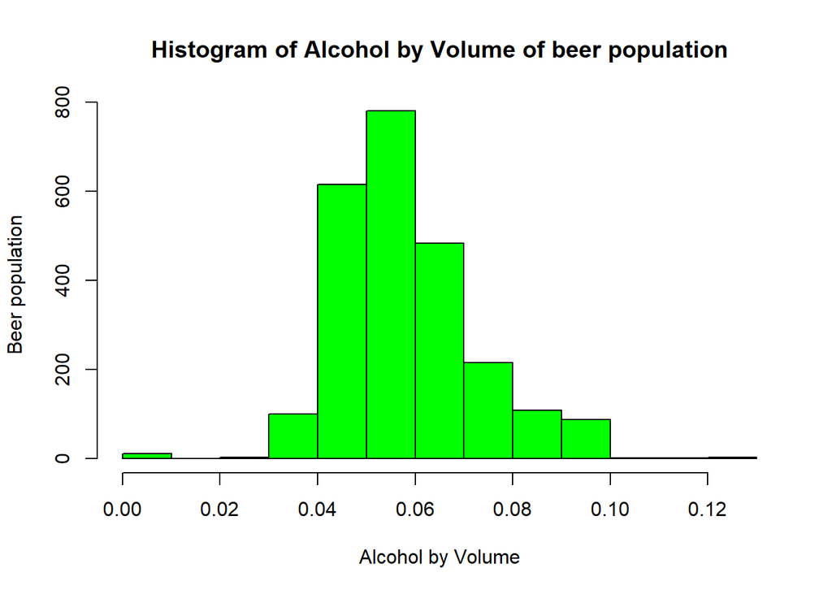

```r
hist(justABV$ABV,
     main="Histogram of Alcohol by Volume of beer population",
     xlab="Alcohol by Volume",
     ylab="Beer population",
     col="green",
     border="black"
     )
```

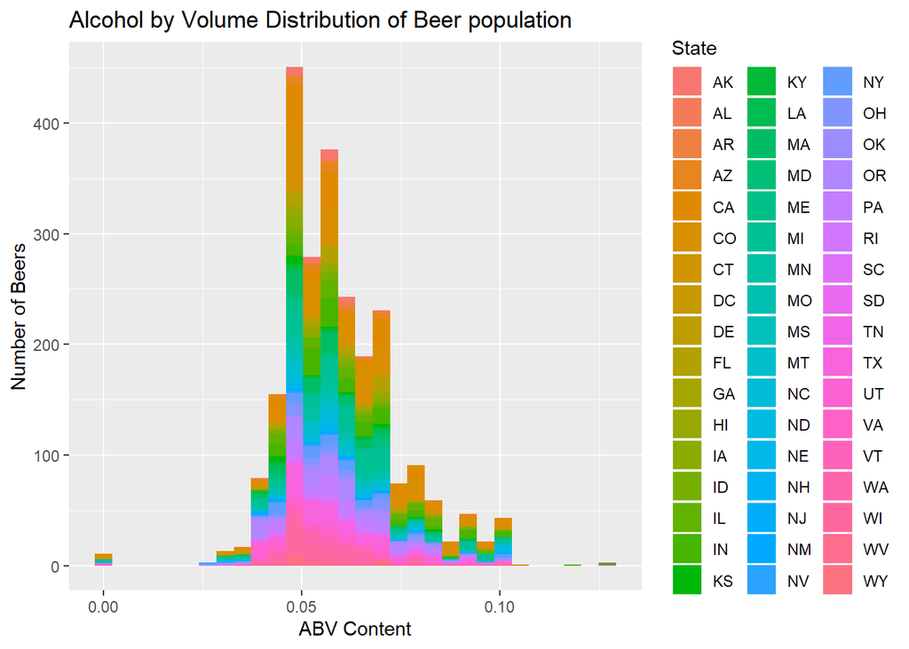

```r
nona%>%ggplot(aes(x=ABV,fill=State))+geom_histogram(bins=30)+ggtitle("Alcohol by Volume Distribution of Beer population")+xlab("ABV Content")+ylab("Number of Beers")
```

```r
#1 sample t-test of ABV data
t.test(x=justABV, conf.int = "TRUE", alternative = "two.sided")
```

```
##
##  One Sample t-test
##
## data:  justABV
## t = 202.43, df = 2409, p-value < 2.2e-16
## alternative hypothesis: true mean is not equal to 0
## 95 percent confidence interval:
##  0.05875595 0.05990546
## sample estimates:
##  mean of x
## 0.05933071
```

```r
justIBU<-nona%>%select(IBU)
summary(justIBU)
```

```
##       IBU
##  Min.   :  4.00
##  1st Qu.: 20.00
##  Median : 38.00
##  Mean   : 46.57
##  3rd Qu.: 66.00
##  Max.   :138.00
```

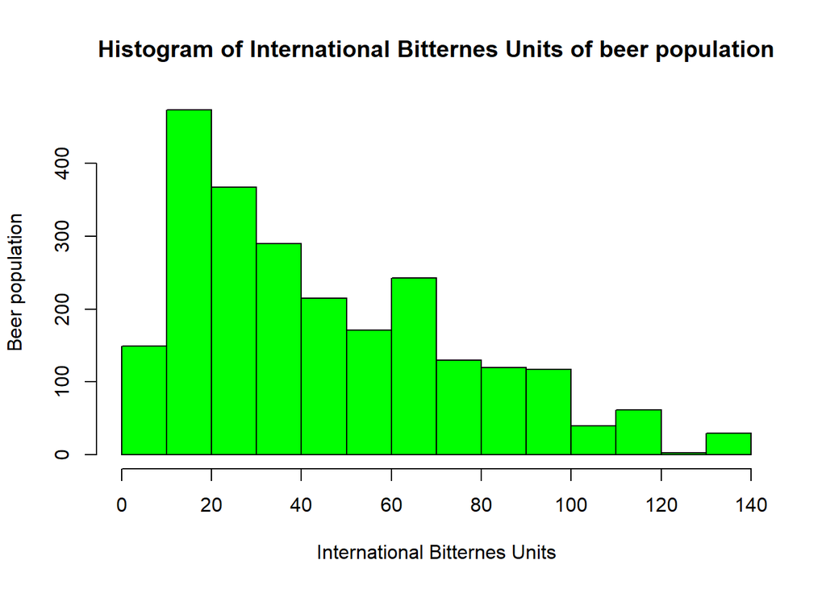

```r
hist(justIBU$IBU,
     main="Histogram of International Bitternes Units of beer population",
     xlab="International Bitternes Units",
     ylab="Beer population",
     col="green",
     border="black"
     )
```

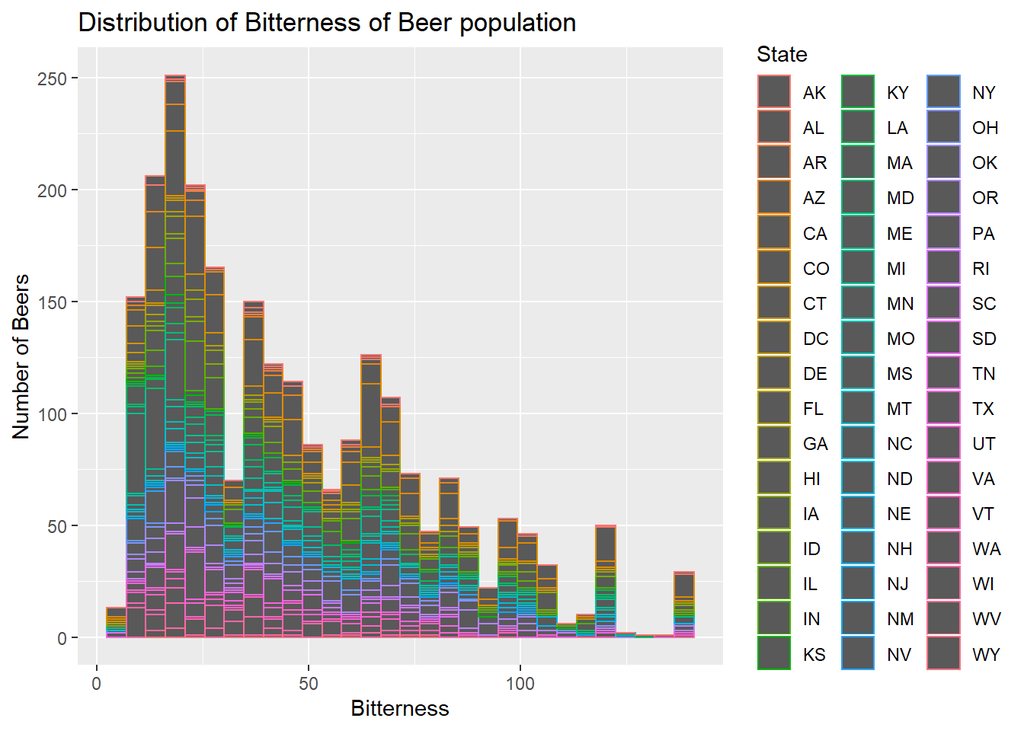

```r
nona%>%ggplot(aes(x=IBU,color=State))+geom_histogram(bins=30)+ggtitle("Distribution of Bitterness of Beer population")+xlab("Bitterness")+ylab("Number of Beers")
```

#7. Is there an apparent relationship between the bitterness # of the beer and its alcoholic content? Draw a scatter plot. #Make your best judgment of a relationship and EXPLAIN your #answer.

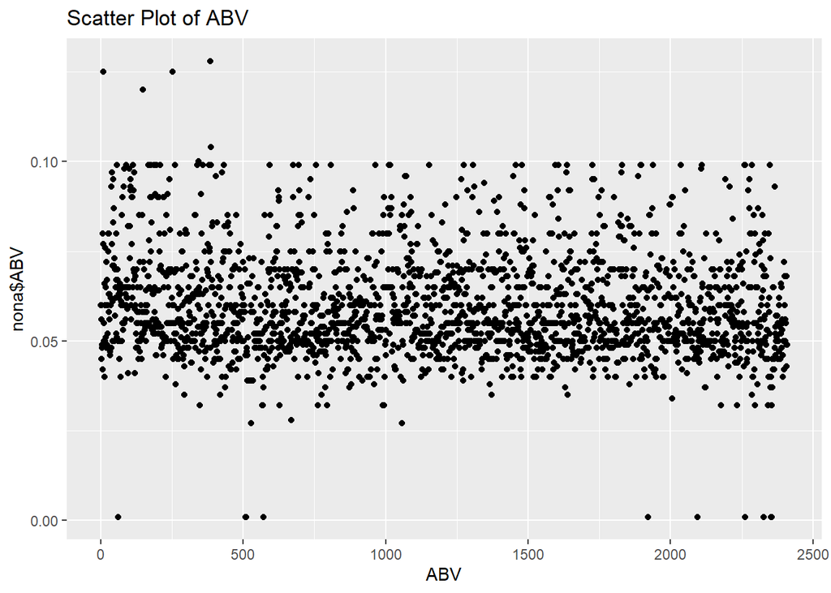

```r
qplot(seq_along(nona$ABV),nona$ABV,main="Scatter Plot of ABV",xlab="ABV")
```

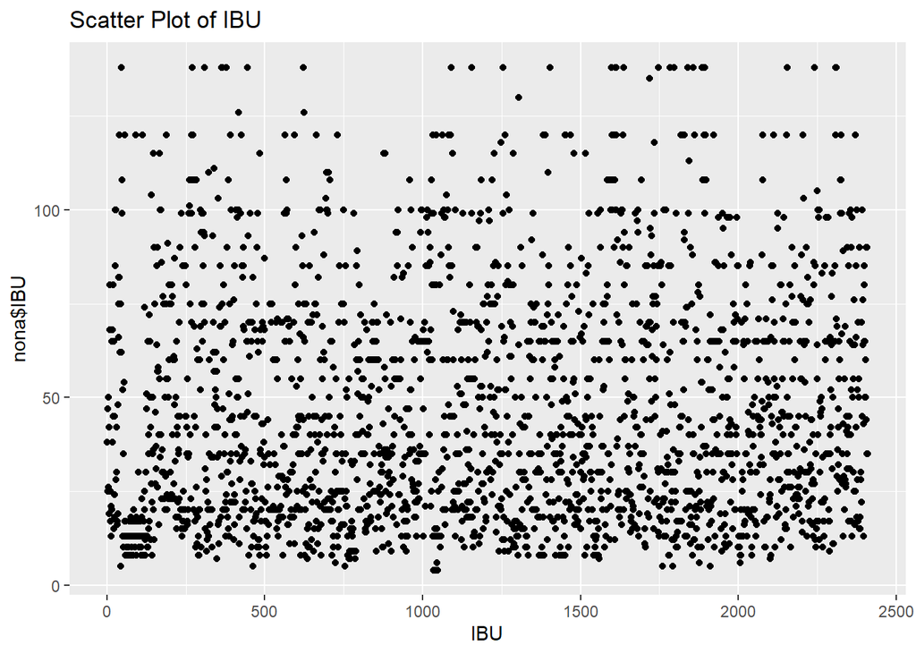

```r
qplot(seq_along(nona$IBU),nona$IBU, main="Scatter Plot of IBU",xlab="IBU")
```

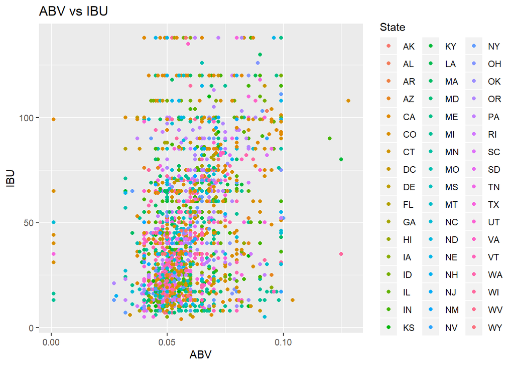

```r
styledf<-nona%>%select(State,Style,ABV,IBU)
styledf%>%ggplot(aes(x=ABV,y=IBU,color=State))+geom_point()+ggtitle("ABV vs IBU")
```

```r
#Code to merge statepop dataset with nona
#statepopmod <- statepop %>% rename(State = abbr)
#nona$State<-trimws(nona$State)
#popuNnonadf<-merge(statepopmod,nona,by="State")
#write.csv(popuNnonadf,file="/Users/malco/Documents/MDS/MDS_6306_DDS/DDS#-CaseStudy1/popuNnonadf.csv",row.names=FALSE)
#fips<chr>,abbr<chr>,full<chr>,pop_2015<dbl>
#Brewery_id<int>,Brewery_name<fctr>,City<fctr>,State<fctr>,Beer_ID<int>,#ABV<dbl>,IBU<int>,Style<fctr>,Ounces<dbl>
#popuNnonadf=read.csv(file="/Users/malco/Documents/MDS/MDS_6306_DDS/DDS-CaseStudy1/popuNnonadf.csv",header=TRUE)
#head(popuNnonadf)

#beerSum=nona%>%group_by(State)%>%summarise(Beer_name=n())
#beerSum<-beerSum%>%rename(BeerNums = Beer_name)

#popuNnonadf%>%select(State,full,pop_2015)
#justbrew<-popuNnonadf%>%group_by(State)%>%summarise(Beer_name=n())
#head(justbrew)
#head(popuNnonadf)
#statebrew<-merge(justbrew,popuNnonadf,by=State)
#head(statebrew)
#statebrew=(abbr,Full State Name, NumBrews,pop2015,pop2015/NumBrews)
```

#Jason’s plots of the us map. #need to add breweries

```r
statesum = count(nona, vars = State)
temp = statepop
statesum$vars = as.character(statesum$vars)
statesum$vars = str_trim(statesum$vars)
statebrew = merge(statesum, temp, by.x = "vars", by.y = "abbr")
names(statebrew)[names(statebrew) == "vars"] <- "abbr"
names(statebrew)[names(statebrew) == "n"] <- "count"
statebrew$per_cap <- statebrew$pop_2015 / statebrew$count
head(statebrew)
```

```
##   abbr count fips       full pop_2015   per_cap
## 1   AK    25   02     Alaska   738432  29537.28
## 2   AL    10   01    Alabama  4858979 485897.90
## 3   AR     5   05   Arkansas  2978204 595640.80
## 4   AZ    47   04    Arizona  6828065 145277.98
## 5   CA   183   06 California 39144818 213906.11
## 6   CO   265   08   Colorado  5456574  20590.85
```

```r
#head(nona)
#head(statebrew)
#allbrews = merge(statebrew, nona, by.x = "abbr", by.y = "State")
#head(allbrews)
```

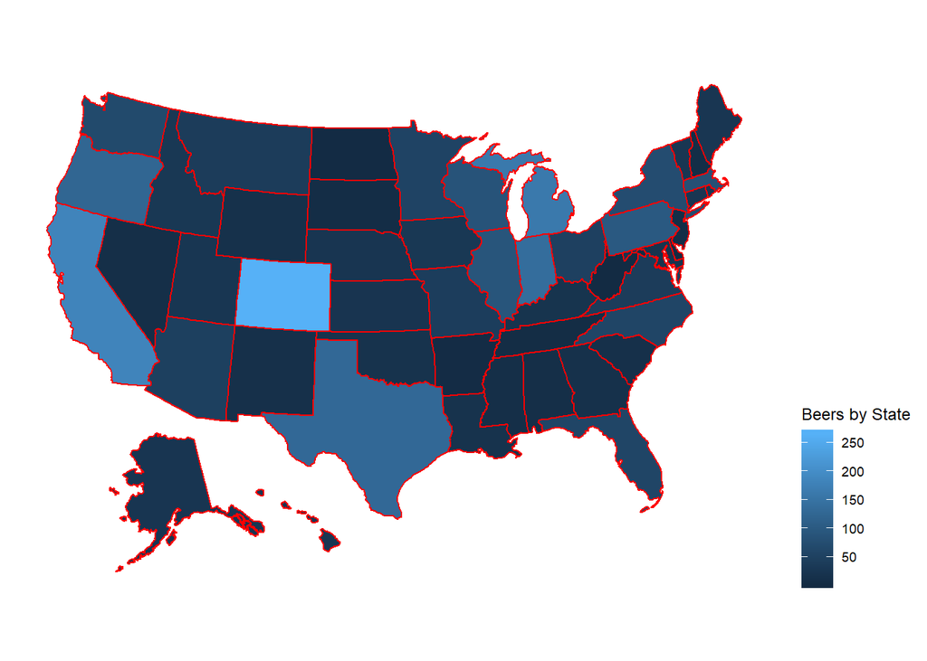

```r
plot_usmap(data = statebrew, values = "count", color = "red") +
  scale_fill_continuous(name = "Beers by State", label = scales::comma) +
  theme(legend.position = "right")
```

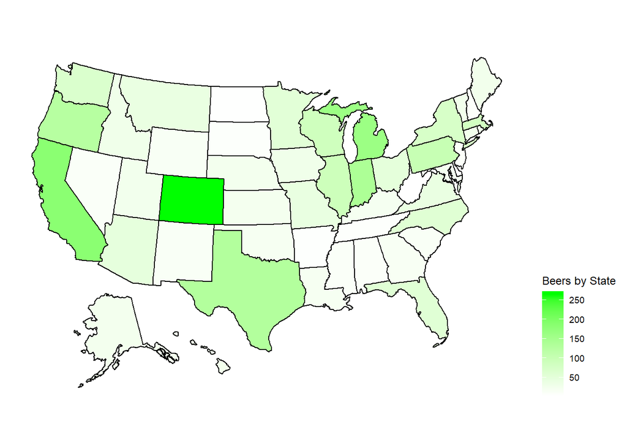

```r
plot_usmap(data = statebrew, values = "count", color = "black") +
  scale_fill_continuous(
    low = "white", high = "green", name = "Beers by State", label = scales::comma
  ) + theme(legend.position = "right")
```

##### states pop div by beers

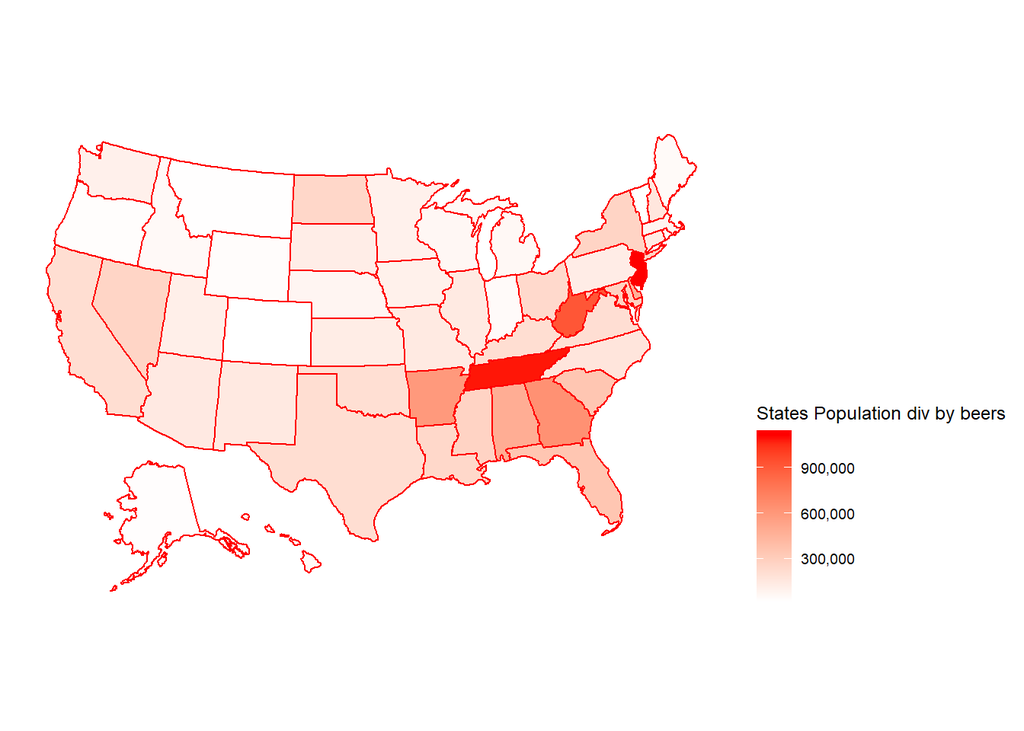

```r
plot_usmap(data = statebrew, values = "per_cap", color = "red") +
  scale_fill_continuous(
    low = "white", high = "red", name = "States Population div by beers", label = scales::comma
  ) + theme(legend.position = "right")
```

# remove n/a’s from the data # merge data to one master data frame

```r
nona$State = as.character(nona$State)
nona$State = str_trim(nona$State)

allbrews = merge(statebrew, nona, by.x = "abbr", by.y = "State")
head(allbrews)
```

```
##   abbr count fips   full pop_2015  per_cap Brewery_id
## 1   AK    25   02 Alaska   738432 29537.28        224
## 2   AK    25   02 Alaska   738432 29537.28        103
## 3   AK    25   02 Alaska   738432 29537.28        103
## 4   AK    25   02 Alaska   738432 29537.28        103
## 5   AK    25   02 Alaska   738432 29537.28        103
## 6   AK    25   02 Alaska   738432 29537.28        103
##                   Brewery_name      City              Beer_name Beer_ID
## 1 Midnight Sun Brewing Company Anchorage          Pleasure Town    2093
## 2  King Street Brewing Company Anchorage              Amber Ale    2436
## 3  King Street Brewing Company Anchorage King Street Blonde Ale    1665
## 4  King Street Brewing Company Anchorage    King Street Pilsner    1706
## 5  King Street Brewing Company Anchorage        King Street IPA    1667
## 6  King Street Brewing Company Anchorage King Street Hefeweizen    1666
##     ABV IBU                    Style Ounces
## 1 0.063  61             American IPA     12
## 2 0.051  15 American Amber / Red Ale     12
## 3 0.049   7      American Blonde Ale     12
## 4 0.055  35           Czech Pilsener     12
## 5 0.060  70             American IPA     12
## 6 0.057  10               Hefeweizen     12
```

# compute the ABV state stats

# compute the IBU state stats

```r
stateABV = allbrews %>%
  group_by(abbr) %>%
  summarise_each(funs(max, min, mean, median, sd), ABV)
stateIBU = allbrews %>%
  group_by(abbr) %>%
  summarise_each(funs(max, min, mean, median, sd), IBU)

stateABV = merge(temp, stateABV, by.x = "abbr", by.y = "abbr")
stateIBU = merge(temp, stateIBU, by.x = "abbr", by.y = "abbr")
```

### ABV usa

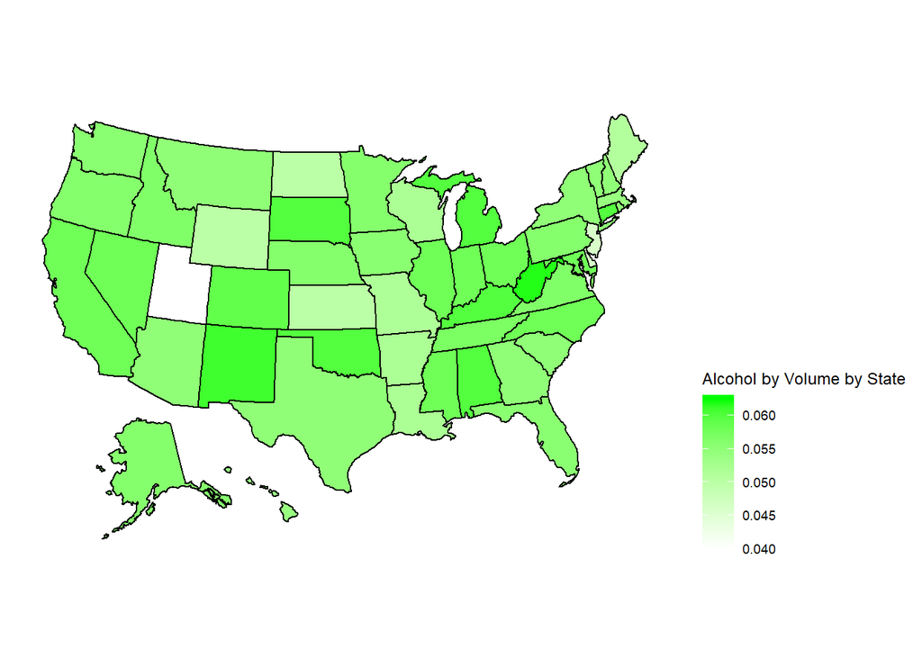

```r
plot_usmap(data = stateABV, values = "median", color = "black") + scale_fill_continuous(low = "white", high = "green", name = "Alcohol by Volume by State"  ) + theme(legend.position =
"right")
```

#### IBU usa

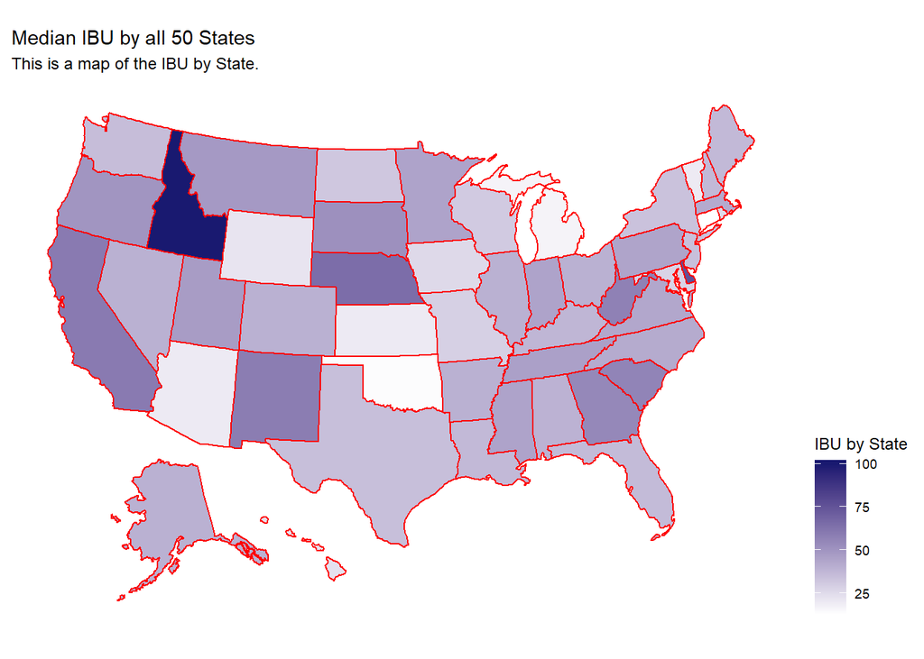

```r
plot_usmap(data = stateIBU, values = "median", color = "red") + labs(title = "Median IBU by all 50 States", subtitle = "This is a map of the IBU by State.") +
  scale_fill_continuous(
    low = "white", high = "midnightblue", name = "IBU by State"  ) + theme(legend.position = "right")
```

#### Max ABV

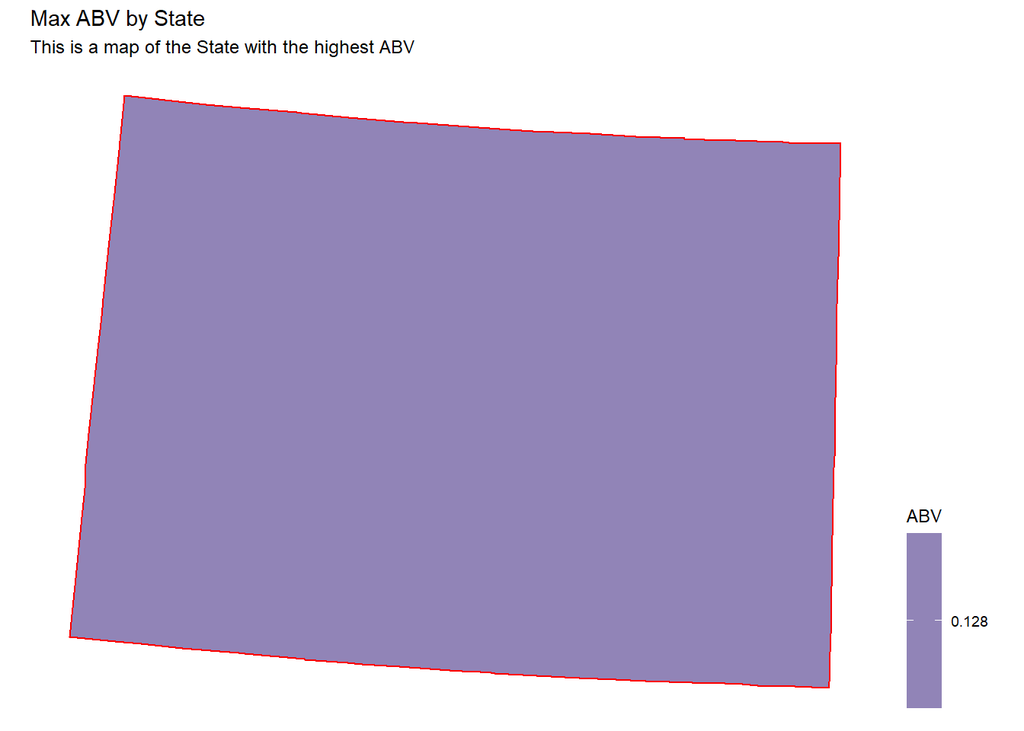

```r
plot_usmap(data = stateABV, values = "max", include = "CO", color = "red") + labs(title = "Max ABV by State", subtitle = "This is a map of the State with the highest ABV") +
  scale_fill_continuous(
    low = "white", high = "midnightblue", name = "ABV"  ) + theme(legend.position = "right")
```

#### Max IBU

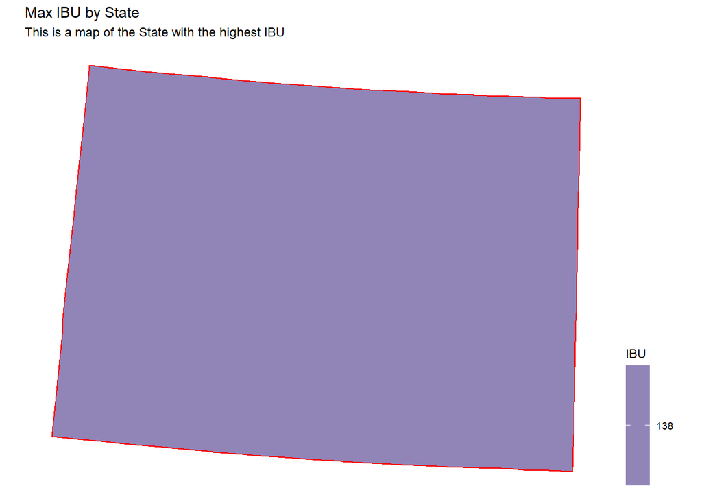

```r
plot_usmap(data = stateIBU, values = "max", include = "CO", color = "red") + labs(title = "Max IBU by State", subtitle = "This is a map of the State with the highest IBU") +
  scale_fill_continuous(
    low = "white", high = "midnightblue", name = "IBU"  ) + theme(legend.position = "right")
```

#linear regression to see if relationship exists between #ABV and IBU

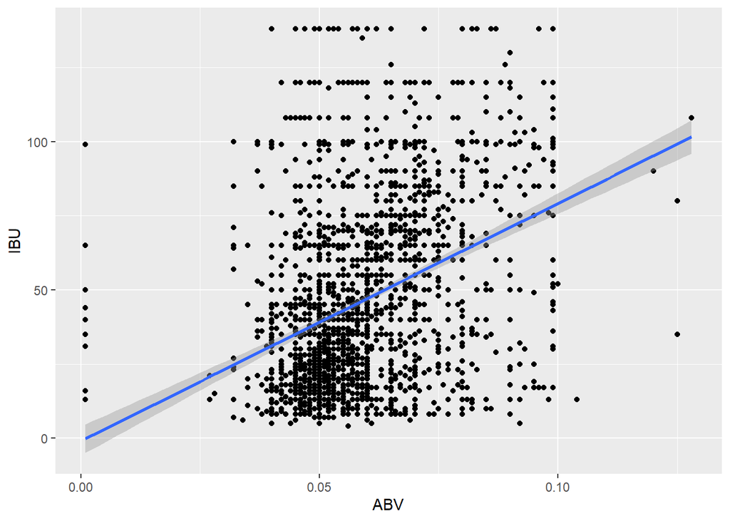

```r
nona%>%ggplot(aes(x=ABV,y=IBU))+geom_point()+geom_smooth(method="lm")
```

```r
fit = lm(IBU~ABV, data = nona)
summary(fit)
```

```
##
## Call:
## lm(formula = IBU ~ ABV, data = nona)
##
## Residuals:
##     Min      1Q  Median      3Q     Max
## -69.361 -20.887  -5.503  16.270 106.920
##
## Coefficients:
##             Estimate Std. Error t value Pr(>|t|)
## (Intercept)  -0.9706     2.4945  -0.389    0.697
## ABV         801.2621    40.8601  19.610   <2e-16 ***
## ---
## Signif. codes:  0 '***' 0.001 '**' 0.01 '*' 0.05 '.' 0.1 ' ' 1
##
## Residual standard error: 28.86 on 2408 degrees of freedom
## Multiple R-squared:  0.1377, Adjusted R-squared:  0.1373
## F-statistic: 384.5 on 1 and 2408 DF,  p-value: < 2.2e-16
```

#Question of interest. What style is most popular, least #by region?

#8. Use KNN - For final presentation

#Jason’s beer style code

```r
styles = c("IPA", "APA", "Blonde ale", "brown ale", "red ale", "ale", "lager", "stout", "cider", "porter", "pilsner", "hefeweizen" ,"pilsener", "witbier", "fruit", "KÃ¶lsch")
beers = data.frame(styles)
beers$nodata = 0
allbrews$class = ""
allbrews$used = FALSE
allbrews$Beer_name = as.character(allbrews$Beer_name)
beers$styles = as.character(beers$styles)
for (i in 1:dim(allbrews)[1]) {
  for (j in 1:dim(beers)[1]) {
    x = beers[j,]$style
    y = allbrews[i,]$Style
    if (str_detect(y, regex(x, ignore_case = TRUE)) & allbrews[i,]$used != TRUE) {
      allbrews[i,]$class = beers[j,]$style
      allbrews[i,]$used = TRUE
    }
  }
}
for (i in 1:dim(allbrews)[1]) {
  if (allbrews[i,]$used == FALSE) {
    allbrews[i,]$class = "other"
  }
  if (allbrews[i,]$class == "Pilsener" | allbrews[i,]$class == "pilsener") {
    allbrews[i,]$class = "pilsner"
  }
}
```

# plot ABV vs IBU to see any relationships

# compute the means for the ABV and IBU by style and then plot

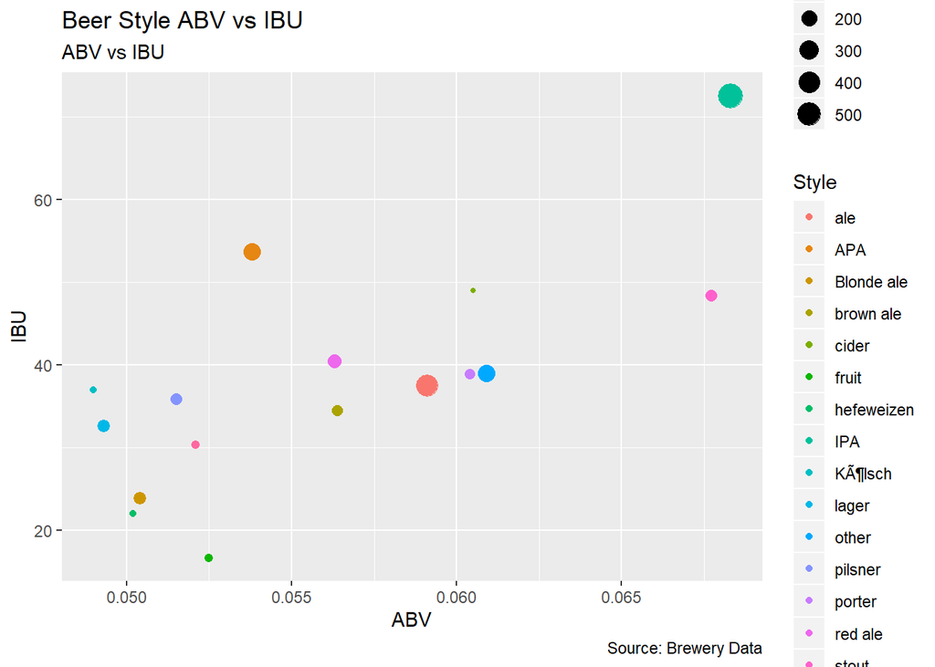

```r
stylesum = count(allbrews, vars = class)
stylemeans = stylesum
stylemeans$ABVmean = 0
stylemeans$IBUmean = 0
stylemeans$ABVtotal = 0
stylemeans$IBUtotal = 0
for (i in 1:dim(allbrews)[1]) {
  for (j in 1:dim(stylesum)[1]) {

    if (allbrews[i,]$class == stylesum[j,]$vars) {
      stylemeans[j,]$ABVtotal = stylemeans[j,]$ABVtotal + allbrews[i,]$ABV
      stylemeans[j,]$IBUtotal = stylemeans[j,]$IBUtotal + allbrews[i,]$IBU
    }

  }
}

for (j in 1:dim(stylemeans)[1]) {
  stylemeans[j,]$ABVmean = stylemeans[j,]$ABVtotal / stylemeans[j,]$n
  stylemeans[j,]$IBUmean = stylemeans[j,]$IBUtotal / stylemeans[j,]$n
}

stylemeans$ABVmean = round(stylemeans$ABVmean, 4)
stylemeans$IBUmean = round(stylemeans$IBUmean, 4)
names(stylemeans)[names(stylemeans) == "vars"] <- "abbr"
names(stylemeans)[names(stylemeans) == "n"] <- "count"


names(stylemeans)[names(stylemeans) == "abbr"] <- "Style"


gg <- ggplot(stylemeans, aes(x=ABVmean, y=IBUmean)) +
  geom_point(aes(col=Style, size=count)) +
  labs(subtitle="ABV vs IBU",
       y="IBU",
       x="ABV",
       title="Beer Style ABV vs IBU",
       caption = "Source: Brewery Data")

plot(gg)
```

#9. Look at, have a direction!